# California Spiny Lobster Abundance

Prepared for ESM 206

Maggie Brickner

11/18/2019

### Introduction

The MPA’s were established in 01/01/2012 and the 2012 samples were taken starting 08/2012, so really just beginning.

[figure not shown]

[figure not shown]

*Figure 1.* *Spiny California lobster (left) and study sites along the Santa Barbara Channel (right).Credit: [Marine Life Photography](https://www.marinelifephotography.com/marine/arthropods/lobsters/panulirus-interruptus.htm) and [EDI Data Portal](https://portal.edirepository.org/nis/mapbrowse?scope=knb-lter-sbc&identifier=77&revision=newest)*

### Data and Methods

Data was collected by divers. When counting Califorbia Spiny Losters at each survey site divers were also trained to observe and categorize lobsters by carapace size, measured in millameters (mm).

### Results

#### A. Changes in Lobster Abundance by Site

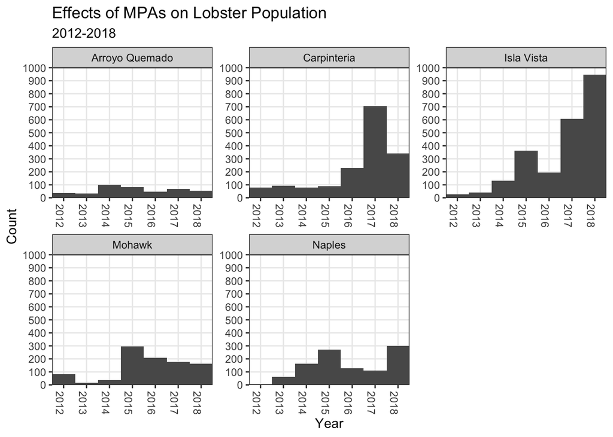

*Figure 2.* *California Spiny Lobster populations at the five survey sites. The Isla Vista and Naples sites are both in Marine Protected Areas (MPAs). These sites were designated as MPAs in 2012. Lobsters surveyed at all sites increased from 2012-2018*

#### B. Shifts in Lobster Size Distribution

The observed lobster size distribution at Carpinteria and Mohawk remained relatively stable. At Arroyo Quemado and Naples the size shifted to have a larger mean in 2018 than 2012. At the Isla Vista site the observed size became dramatically larger over the same time period. See *Figure 4* for comparison of the mean lobster size and distribution at MPA and non-MPA sites.

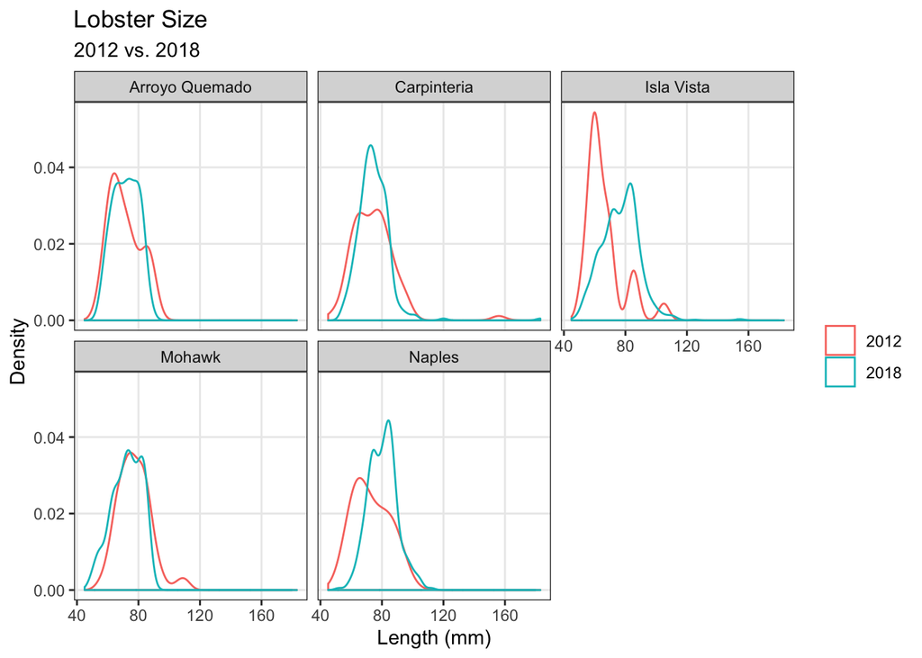

#### C. Mean lobster size at MPA vs. non-MPA sites in 2012 and 2018

###### 1. Mean lobster size comparison in 2012 between MPA and non-MPA areas.

- H<sub>0</sub>: There is *no* significant difference in mean lobster size in 2012 between MPA and non-MPA sites.
- H<sub>A</sub>: There *is* a significant difference in mean lobster size in 2012 between MPA and non-MPA sites.

$\alpha$ = 0.05

Mean 2012 lobster size (mm) measured at Marine Protected Areas (67.38) and non-Marine Protected Areas (74.92) differ significantly (t(42.09) = -3.25 *p* = 0.002).

In 2012 lobsters at non-MPA sites were significantly larger than those at recently established MPA sites.

##### 2. For 2018 observations, is there a significant difference in lobster size between MPA and non-MPA sites?

- H<sub>0</sub>: There is no significant difference in mean lobster size in 2018 between MPA and non-MPA sites.
- H<sub>A</sub>: There is a significant difference in mean lobster size in 2018 between MPA and non-MPA sites.

$\alpha$ = 0.05

Mean 2018 lobster size (mm) measured at Marine Protected Areas (77.57) and non-Marine Protected Areas (73.62) differ significantly (t(1239.51) = 7.31 *p* < 0.001).

##### 3. For MPA sites only, is there a significant mean size difference in lobsters observed in 2012 vs. 2018?

- H<sub>0</sub>: There is no significant difference in mean lobster size between 2012 and 2018 at MPA sites.
- H<sub>A</sub>: There is a significant difference in mean lobster size between 2012 and 2018 at MPA sites.

$\alpha$ = 0.05

The mean lobster size (mm) at MPA sites measured in 2012 (67.38) and 2018 (77.57) differs significantly (t(32.5) = -4.69 *p* < 0.001).

##### 4. For non-MPA sites only, is there a significant mean size difference in lobsters observed in 2012 vs. 2018?

- H<sub>0</sub>: There is no significant difference in mean lobster size between 2012 and 2018 at non-MPA sites.
- H<sub>A</sub>: There is a significant difference in mean lobster size between 2012 and 2018 at non-MPA sites.

$\alpha$ = 0.05

The mean lobster size at non-MPA sites measured in 2012 (74.92) and 2018 (73.62) does not differ significantly (t(296.01) = 1.33 *p* = 0.183).

*Figure 4.* *Comparison of mean lobster size (mm) in 2012 and 2018 at MPA and non-MPA sites. The mean carapace size increased by 10 mm at MPA sites between 2012, when they were first established and 2018. Non-MPA sites did not exhibit the same large increase over that time.*

| Lobster Metrics Year | Lobster Metrics Marine protected area | Lobster Metrics Mean size (mm) | Lobster Metrics Standard deviation size (mm) | Lobster Metrics Sample size (n) |
| --- | --- | --- | --- | --- |
| 2012 | MPA | 67.37500 | 12.15425 | 32 |
| 2012 | non-MPA | 74.92462 | 12.41412 | 199 |
| 2018 | MPA | 77.56672 | 11.70341 | 1244 |
| 2018 | non-MPA | 73.61996 | 10.09438 | 561 |

### References

Reed D. 2019. SBC LTER: Reef: Abundance, size and fishing effort for California Spiny Lobster (Panulirus interruptus), ongoing since 2012. Environmental Data Initiative. https://doi.org/10.6073/pasta/a593a675d644fdefb736750b291579a0. Dataset accessed 10/30/2019.